# ch14.DataVisualization

동그랑땡

2023-10-02

## 14장 데이터 시각화

### 14.2.1 ggplot2 패키지 함수 사용 예제

관련 패키지 호출

```r
library(tidyverse)
```

iris의 Sepal.Length와 Sepal.Width로 산점도 그리기

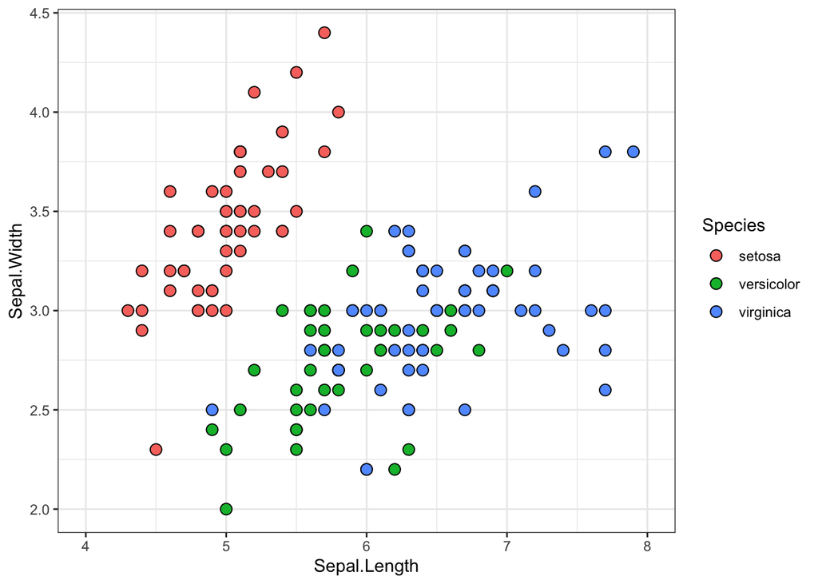

```r
ggplot(data = iris,
       mapping = aes(x = Sepal.Length,
                     y = Sepal.Width,
                     fill = Species)) +
  geom_point(shape = 21, size = 3) +
  coord_cartesian(xlim = c(4, 8)) +
  theme_bw()
```

### 14.3.1 실습 데이터셋 준비

현재 작업 경로 확인

```r
getwd()
```

```
## [1] "/Users/jaahyun/Documents/R_withNasungho-practice/Ch14.DataVizualization"
```

현재 작업 경로에 포함된 폴더명과 파일명을 문자형 벡터로 출력

```r
list.files()
```

```
## [1] "APT_Dataset_Gangnam_2020.RDS" "Ch 14 Data Vizualization.R"
## [3] "Ch14.DataVizualization_files" "Ch14.DataVizualization.html"
## [5] "Ch14.DataVizualization.Rmd"
```

RDS 파일을 읽고 데이터프레임 apt 생성

```r
apt <- readRDS(file = 'APT_Dataset_Gangnam_2020.RDS')
```

### 14.2.2 한글 폰트 추가

관련 패키지 호출

```r
# install.packages("showtext")
library(showtext)
```

구글폰트에서 Nanum Gothic과 Gamja Flower 설치

```r
font_add_google(name = 'Nanum Gothic', family = 'NanumGothic')
font_add_google(name = 'Gamja Flower', family = 'GamjaFlower')
```

설치한 구글폰트를 사용하도록 설정

```r
showtext_auto()
```

### 14.4.1 히스토그램 기본형 그리기

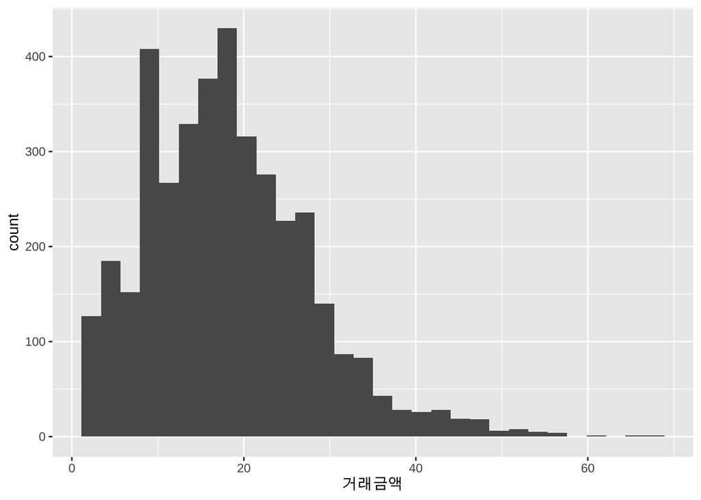

```r
ggplot(data = apt, mapping = aes(x = 거래금액)) +
  geom_histogram()
```

### 14.4.2 히스토그램 막대 간격과 채우기 및 테두리 색 설정

거래금액의 최솟값과 최댓값 확인

```r
range(apt$거래금액)
```

```
## [1]  1.5 67.0
```

# 최솟값보다 작고 최댓값보다 큰 막대 간격 설정

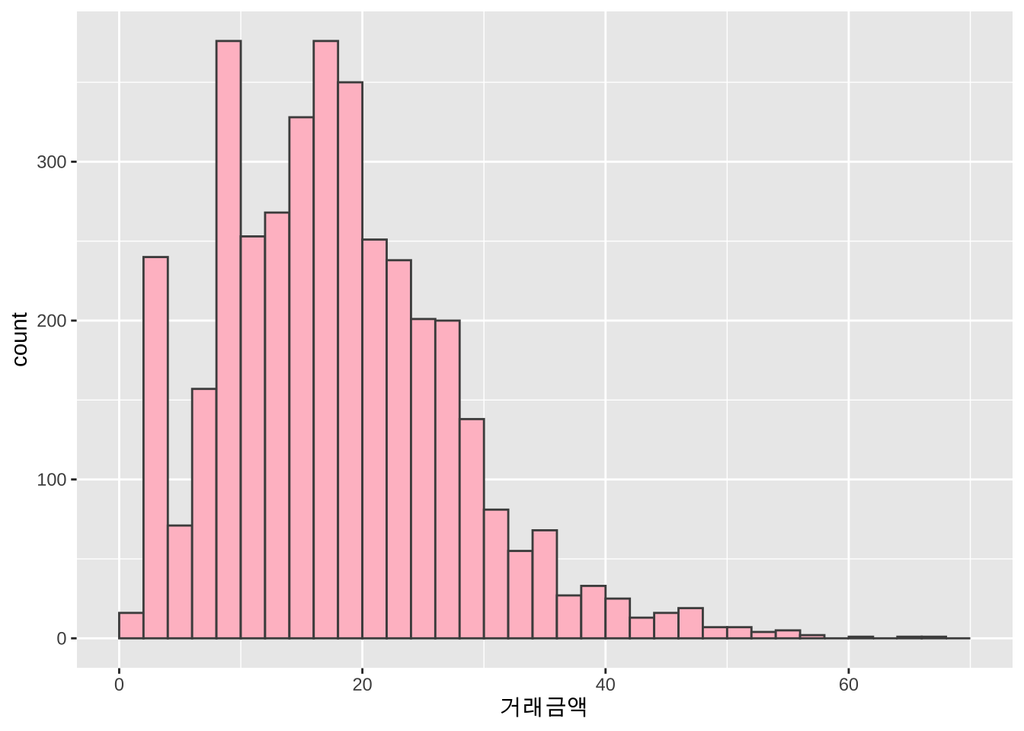

```r
breaks <- seq(from = 0, to = 70, by = 2)

# 막대 간격과 채우기 및 테두리 색 추가한 히스토그램 그리기
ggplot(data = apt, mapping = aes(x = 거래금액)) +
  geom_histogram(breaks = breaks, color = 'gray30', fill = 'pink')
```

### 14.4.3 히스토그램 제목 및 완성된 테마 추가

labs, theme 사용

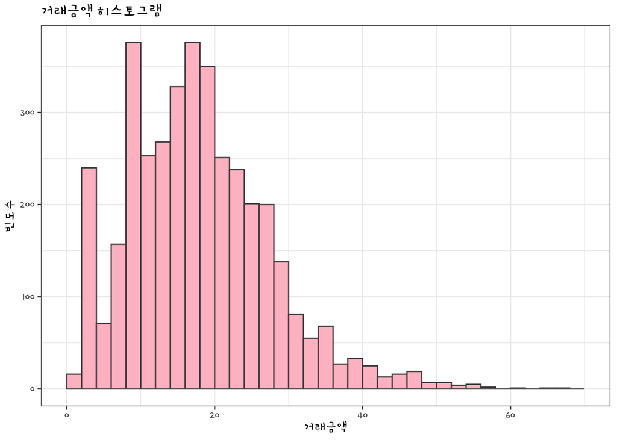

```r
ggplot(data = apt, mapping = aes(x = 거래금액)) +
  geom_histogram(breaks = breaks, color = 'gray30', fill = 'pink') +
  labs(title = '거래금액 히스토그램', x = '거래금액', y = '빈도수') +
  theme_bw(base_family = 'GamjaFlower')
```

### 14.4.4 히스토그램 테마 수정하기

hjust 로 제목 가운데로 옮기기 element_black() -> theme에서 특정요소 제거시 사용.

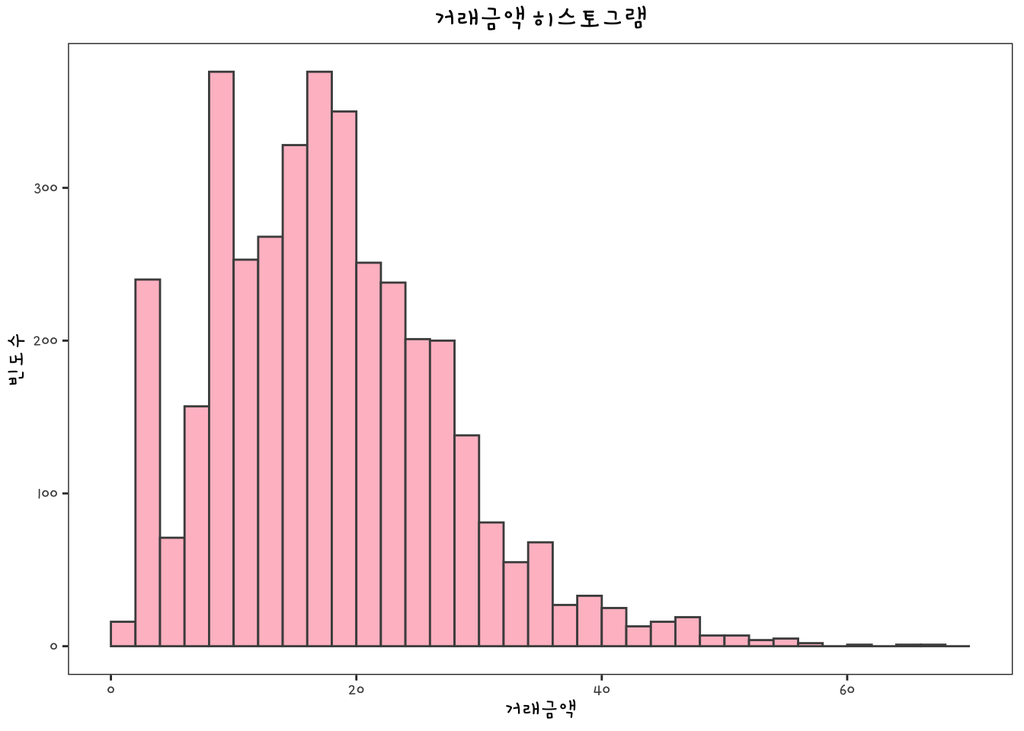

```r
ggplot(data = apt, mapping = aes(x = 거래금액)) +
  geom_histogram(breaks = breaks, color = 'gray30', fill = 'pink') +
  labs(title = '거래금액 히스토그램', x = '거래금액', y = '빈도수') +
  theme_bw(base_family = 'GamjaFlower') +
  theme(plot.title = element_text(size = 14, hjust = 0.5),
        panel.grid = element_blank())
```

사용자 테마 설정

```r
mytheme <- theme_bw(base_family = 'NanumGothic') +
  theme(plot.title = element_text(size = 14, hjust = 0.5),
        panel.grid = element_blank())
```

항상 theme함수가 마지막 ( 여기선 theme_bw 다음에 theme 함수가 온다) theme_bw가 마지막으로 가면 모든 내용이 theme_bw 로 덮어씌워진다.

### 14.5.1 일변량 상자 수염 그림

사용자 테마인 mytheme은 맨 마지막에 추가한다.

boxplot에서 이상치가 없을때에는 최댓값,최솟값에 가로선을 긋는다.(3사분위수 + 1.5 IQR, 1사분위수 - 1.5IQR 대신)

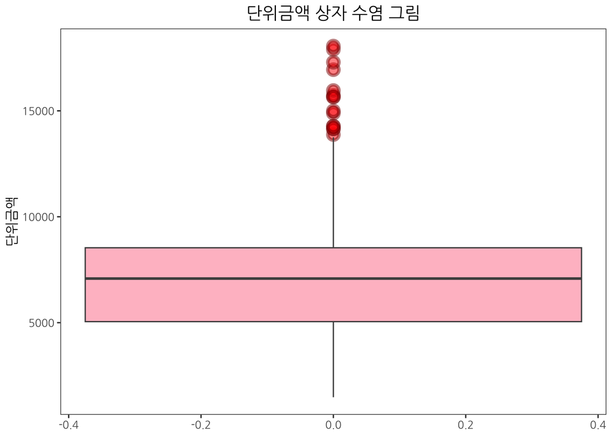

```r
ggplot(data = apt, mapping = aes(y = 단위금액)) +
  geom_boxplot(color = 'gray30', fill = 'pink',
               outlier.color = 'darkred', outlier.fill = 'red',
               outlier.shape = 21, outlier.size = 3,
               outlier.stroke = 2, outlier.alpha = 0.5) +
  labs(title = '단위금액 상자 수염 그림') +
  mytheme
```

### 14.5.2 이변량 상자 수염 그림

x축에 범주형 데이터 사용. y축에 연속형 데이터 사용. > 이변량

codeHeatNm이 결측값이 아닌 행만 남겨서 apt1 생성

```r
apt1 <- apt %>% filter(!is.na(x = codeHeatNm))
head(apt1)
```

```
##           아파트                      도로명주소 월 일 전용면적 층 거래금액
## 1   대치아이파크    서울특별시 강남구 선릉로 222  1  2  114.970 10    30.00
## 2     우성캐릭터    서울특별시 강남구 언주로 118  1  2  132.940  5    17.00
## 3     포스코더샵    서울특별시 강남구 삼성로 417  1  2  139.540  3    24.70
## 4       까치마을 서울특별시 강남구 광평로19길 10  1  3   39.600 13     8.70
## 5           미성  서울특별시 강남구 압구정로 113  1  3   74.400 13    21.00
## 6 현대힐스테이트 서울특별시 강남구 삼성로111길 8  1  3   84.679  5    22.45
##   단위금액 금액구분 kaptDongCnt kaptdaCnt kaptTarea privArea codeSaleNm
## 1     8611 1억 미만          11       768 147441.71 78559.10       분양
## 2     4220 1억 미만           2       199 100496.73 29658.06       분양
## 3     5841 1억 미만           4       276  72318.86 41857.92       분양
## 4     7250 1억 미만           7      1403  83490.86 57555.18       분양
## 5     9315 1억 미만           9       911 131841.00 93827.80       분양
## 6     8749 1억 미만          12       926 147738.62 69975.80       분양
##   codeHeatNm codeMgrNm codeHallNm kaptUsedate
## 1   지역난방  위탁관리     계단식    20080603
## 2   지역난방  위탁관리     계단식    19981107
## 3   지역난방  위탁관리     계단식    20040930
## 4   지역난방  위탁관리     복도식    19930908
## 5   지역난방  자치관리     혼합식    19871205
## 6   지역난방  위탁관리     혼합식    20081210
```

apt1의 codeHeatNm별 단위금액의 상자 수염 그림 그리기

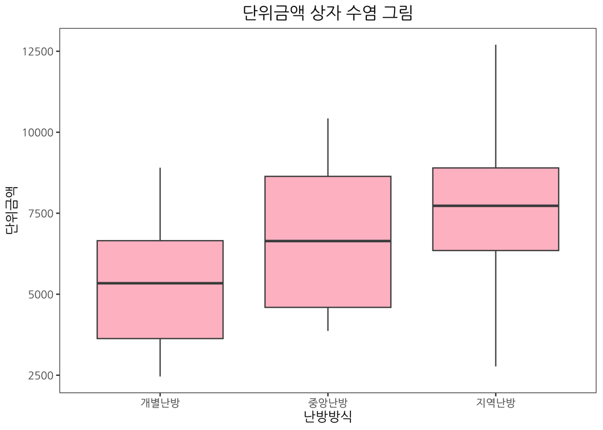

```r
ggplot(data = apt1, mapping = aes(x = codeHeatNm, y = 단위금액)) +
  geom_boxplot(color = 'gray30', fill = 'pink',
               outlier.color = 'darkred', outlier.fill = 'red',
               outlier.shape = 21, outlier.size = 3,
               outlier.stroke = 2, outlier.alpha = 0.5) +
  labs(title = '단위금액 상자 수염 그림', x = '난방방식') +
  mytheme
```

### 14.5.3 색 바꾸고 범례 추가하기

fill 함수를 pink 대신 codeHeatNm 컬럼값 사용. 컬럼값에 따라 다르게 채우기 색 설정.

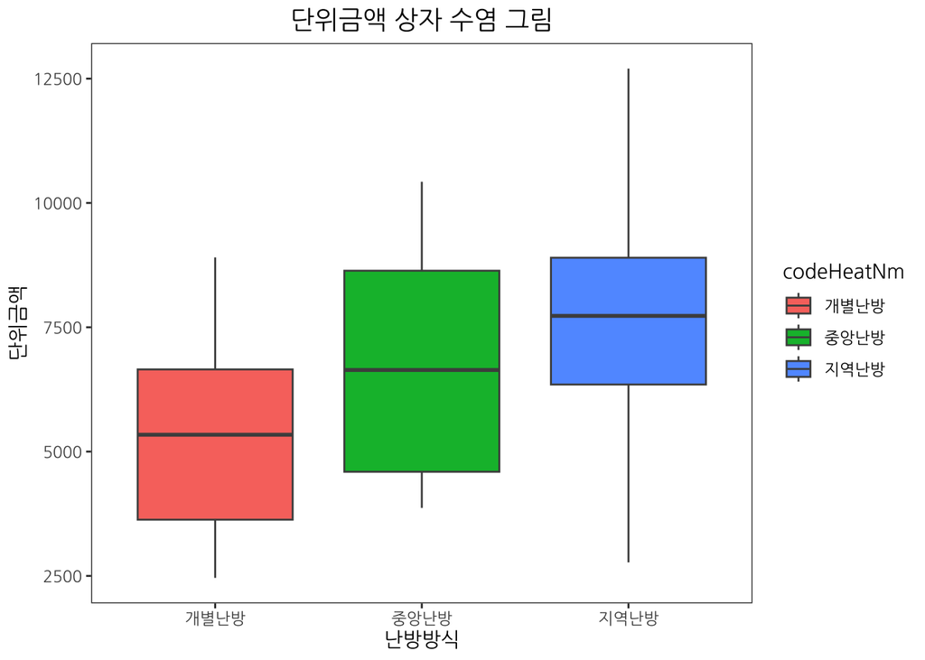

```r
ggplot(data = apt1, mapping = aes(x = codeHeatNm, y = 단위금액)) +
  geom_boxplot(mapping = aes(fill = codeHeatNm), color = 'gray30',
               outlier.color = 'darkred', outlier.fill = 'red',
               outlier.shape = 21, outlier.size = 3,
               outlier.stroke = 2, outlier.alpha = 0.5) +
  labs(title = '단위금액 상자 수염 그림', x = '난방방식') +
  mytheme
```

### 14.5.4 범례 제거하기

theme(legend.position = ‘none’)

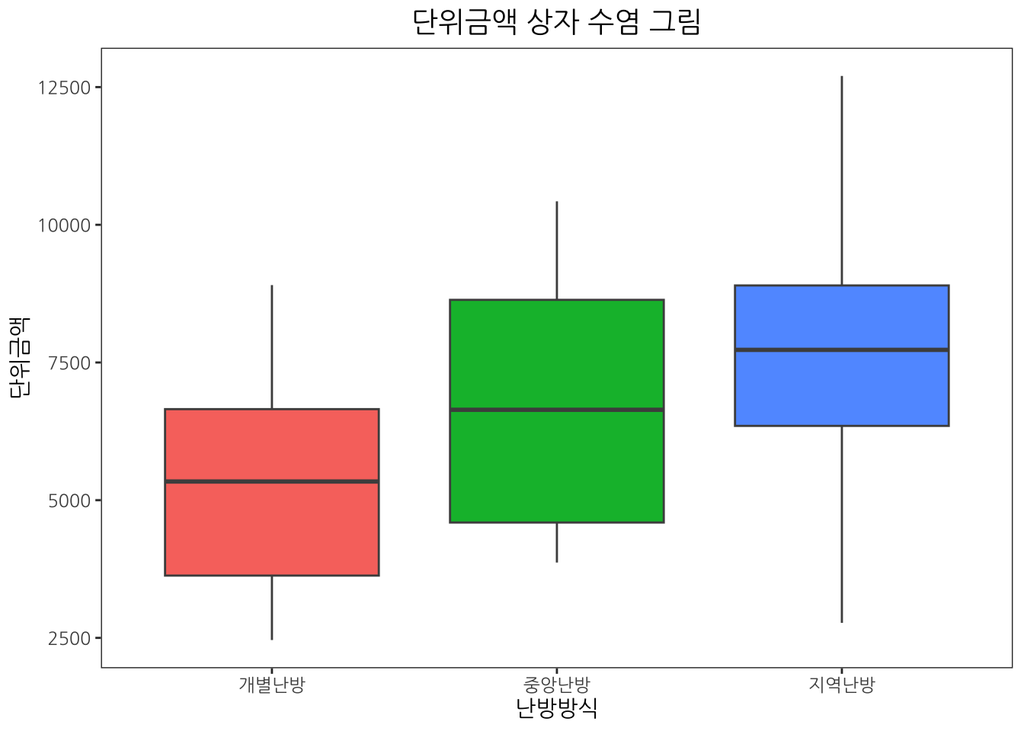

```r
ggplot(data = apt1, mapping = aes(x = codeHeatNm, y = 단위금액)) +
  geom_boxplot(mapping = aes(fill = codeHeatNm), color = 'gray30',
               outlier.color = 'darkred', outlier.fill = 'red',
               outlier.shape = 21, outlier.size = 3,
               outlier.stroke = 2, outlier.alpha = 0.5) +
  labs(title = '단위금액 상자 수염 그림', x = '난방방식') +
  mytheme +
  theme(legend.position = 'none')
```

### 14.6.1 일변량 막대 그래프 그리기

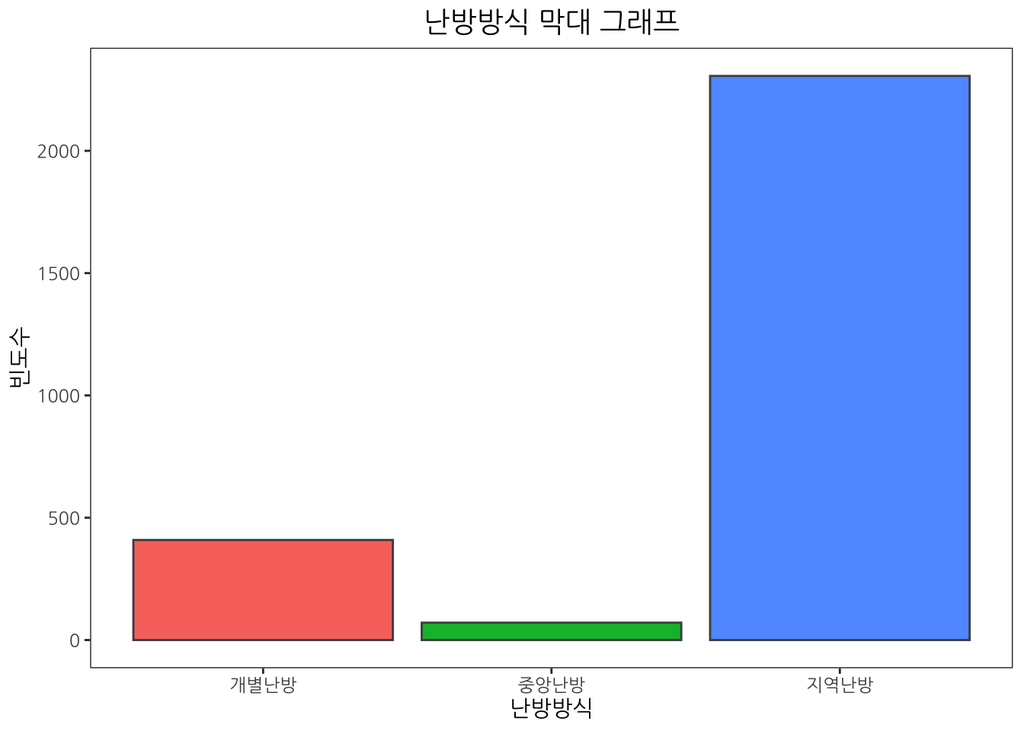

```r
ggplot(data = apt1, mapping = aes(x = codeHeatNm)) +
  geom_bar(mapping = aes(fill = codeHeatNm), color = 'gray30') +
  labs(title = '난방방식 막대 그래프', x = '난방방식', y = '빈도수') +
  mytheme +
  theme(legend.position = 'none')
```

### 14.6.2 이변량 막대 그래프 그리기

apt1의 codeHeatNm 기준으로 빈도수를 계산하고 heatCnt 생성

```r
apt1 %>% group_by(codeHeatNm) %>% summarise(freq = n()) -> heatCnt

# heatCnt의 구조 확인
str(object = heatCnt)
```

```
## tibble [3 × 2] (S3: tbl_df/tbl/data.frame)
##  $ codeHeatNm: chr [1:3] "개별난방" "중앙난방" "지역난방"
##  $ freq      : int [1:3] 409 71 2306
```

heatCnt의 codeHeatNm별 freq의 크기로 막대 그래프 그리기

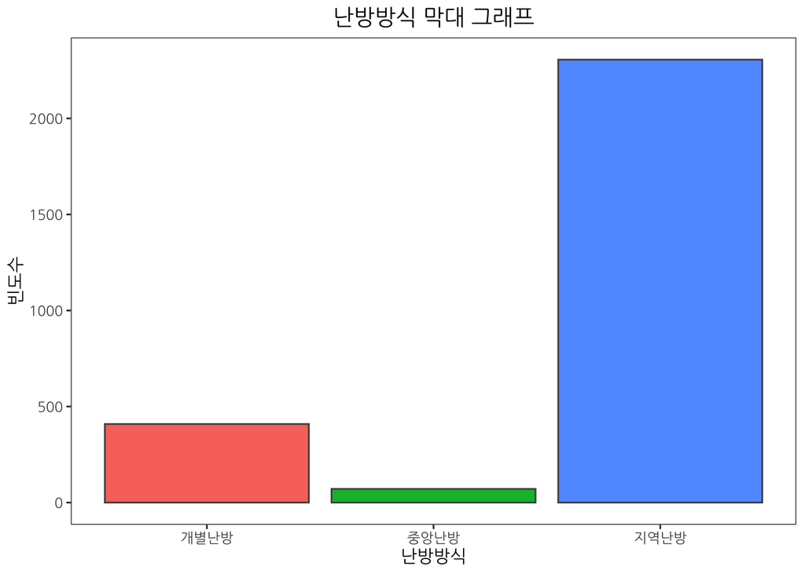

```r
ggplot(data = heatCnt, mapping = aes(x = codeHeatNm, y = freq)) +
  geom_col(mapping = aes(fill = codeHeatNm), color = 'gray30') +
  labs(title = '난방방식 막대 그래프', x = '난방방식', y = '빈도수') +
  mytheme +
  theme(legend.position = 'none')
```

### 14.6.3 빈도수 추가하기

geom_text, coord_cartesian

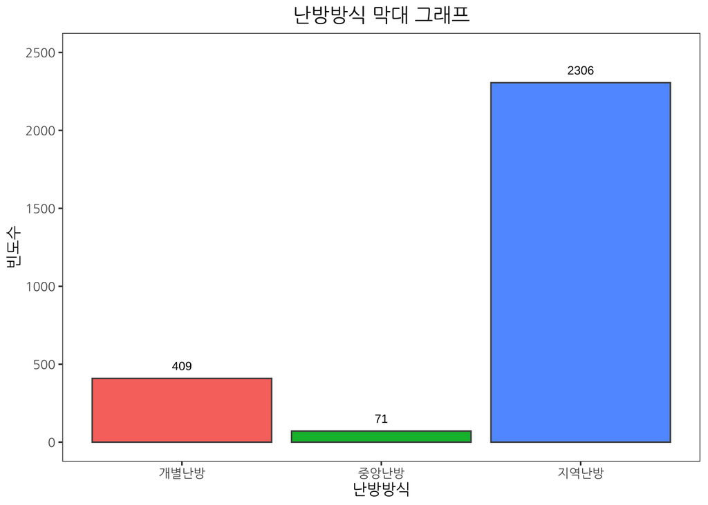

```r
ggplot(data = heatCnt, mapping = aes(x = codeHeatNm, y = freq)) +
  geom_col(mapping = aes(fill = codeHeatNm), color = 'gray30') +
  coord_cartesian(ylim = c(0, 2500)) +
  geom_text(mapping = aes(label = freq),
            vjust = -1, size = 3) +
  labs(title = '난방방식 막대 그래프', x = '난방방식', y = '빈도수') +
  mytheme +
  theme(legend.position = 'none')
```

### 14.7.1 이변량 선 그래프 그리기

apt1의 월별 평균단위금액을 계산하여 monthMean 생성

```r
apt1 %>%
  group_by(월) %>%
  summarise(평균단위금액 = mean(단위금액)) -> monthMean

# monthMean의 구조 확인
str(object = monthMean)
```

```
## tibble [12 × 2] (S3: tbl_df/tbl/data.frame)
##  $ 월          : int [1:12] 1 2 3 4 5 6 7 8 9 10 ...
##  $ 평균단위금액: num [1:12] 7089 7238 6679 6868 7009 ...
```

monthMean의 월별 평균단위금액으로 선 그래프 그리기

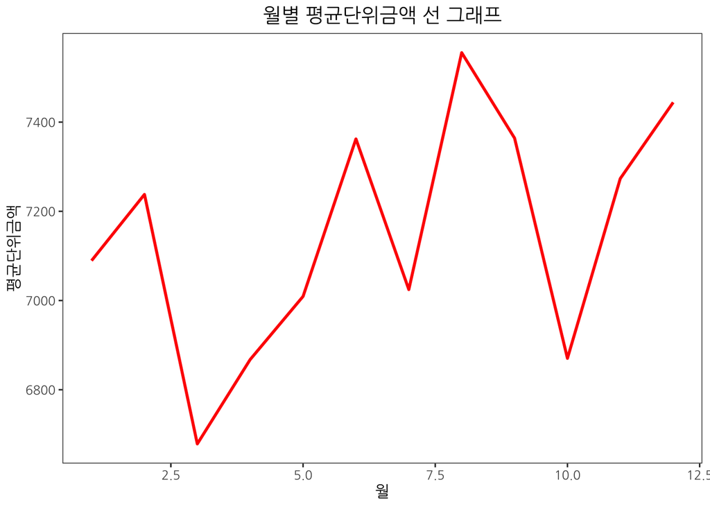

```r
ggplot(data = monthMean, mapping = aes(x = 월, y = 평균단위금액)) +
  geom_line(color = 'red', linetype = 1, linewidth = 1) +
  labs(title = '월별 평균단위금액 선 그래프') +
  mytheme
```

### 14.7.2 데이터 처리 : 단위금액 컬럼의 평균을 갖는 데이터프레임 생성

apt1을 월, codeHeatNm 기준으로 평균단위금액을 계산하여 monthMean2 생성 .groups = ‘drop’ 사용

```r
apt1 %>%
  group_by(월, codeHeatNm) %>%
  summarise(평균단위금액 = mean(단위금액), .groups = 'drop') -> monthMean2

# monthMean2의 구조 확인
str(object = monthMean2)
```

```
## tibble [36 × 3] (S3: tbl_df/tbl/data.frame)
##  $ 월          : int [1:36] 1 1 1 2 2 2 3 3 3 4 ...
##  $ codeHeatNm  : chr [1:36] "개별난방" "중앙난방" "지역난방" "개별난방" ...
##  $ 평균단위금액: num [1:36] 5224 6194 7477 5435 6044 ...
```

long type 데이터프레임 완성.

monthMean2의 처음 여섯 행만 출력

```r
head(x = monthMean2)
```

```
## # A tibble: 6 × 3
##      월 codeHeatNm 평균단위금액
##   <int> <chr>             <dbl>
## 1     1 개별난방          5224.
## 2     1 중앙난방          6194
## 3     1 지역난방          7477.
## 4     2 개별난방          5435.
## 5     2 중앙난방          6044.
## 6     2 지역난방          7554.
```

### 14.7.3 Long Type 데이터프레임으로 선 그래프 그리기

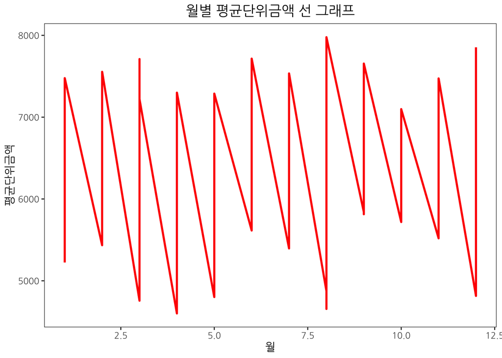

```r
ggplot(data = monthMean2, mapping = aes(x = 월, y = 평균단위금액)) +
  geom_line(color = 'red', linewidth = 1) +
  labs(title = '월별 평균단위금액 선 그래프') +
  mytheme
```

예상치 못한 그래프가 나타남. 36개 컬럼값을 모두 하나의 선으로 이었기 때문.

### 14.7.4 Long Type 데이터프레임으로 선 그래프 그릴 때 group으로 묶기

monthMean2의 월을 범주형으로 변환하고 monthMean2에 재할당 x축 ’월’이 소수점으로 나오는 것을 방지하기위함.

```r
monthMean2 %>% mutate(월 = as.factor(x = 월)) -> monthMean2
str(monthMean2)
```

```
## tibble [36 × 3] (S3: tbl_df/tbl/data.frame)
##  $ 월          : Factor w/ 12 levels "1","2","3","4",..: 1 1 1 2 2 2 3 3 3 4 ...
##  $ codeHeatNm  : chr [1:36] "개별난방" "중앙난방" "지역난방" "개별난방" ...
##  $ 평균단위금액: num [1:36] 5224 6194 7477 5435 6044 ...
```

monthMean2의 월별 평균단위금액으로 선 그래프 그리기 codeHeatNm으로 그룹을 지정해야 원하는 그래프를 그릴 수 있음 aes에 group 인수 사용.

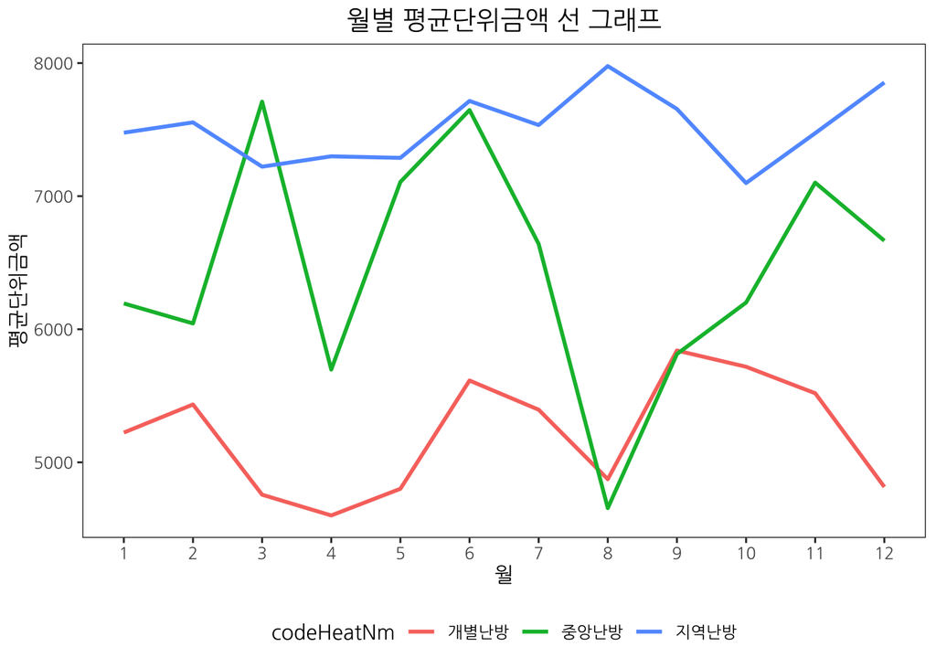

```r
ggplot(data = monthMean2, mapping = aes(x = 월, y = 평균단위금액)) +
  geom_line(mapping = aes(group = codeHeatNm, color = codeHeatNm),
            size = 1) +
  labs(title = '월별 평균단위금액 선 그래프') +
  mytheme +
  theme(legend.position = 'bottom')
```

### 14.8.1 이변량 산점도 그리기

geom_point

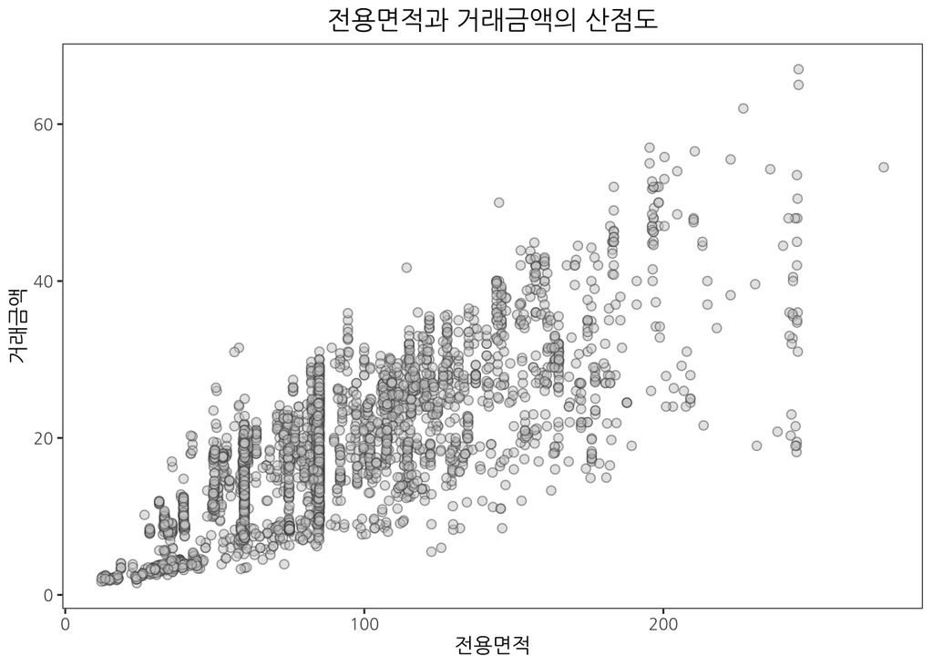

```r
ggplot(data = apt, mapping = aes(x = 전용면적, y = 거래금액)) +
  geom_point(color = 'gray30', fill = 'gray80', shape = 21,
             size = 2, alpha = 0.5, stroke = 0.5) +
  labs(title = '전용면적과 거래금액의 산점도') +
  mytheme
```

### 14.8.2 수직선/수평선으로 구역 나누기

geom_vline, geom_hline

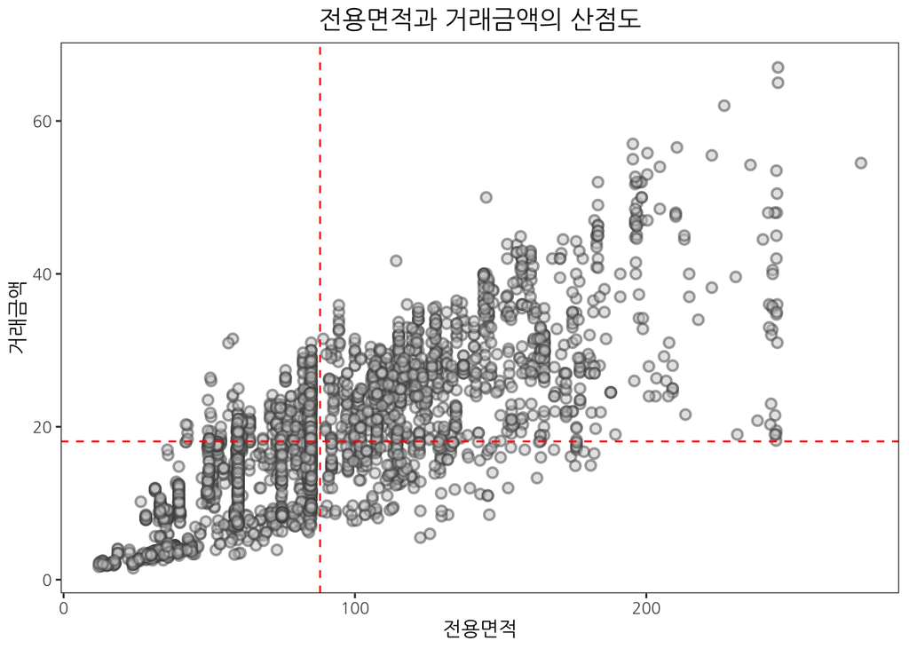

```r
ggplot(data = apt, mapping = aes(x = 전용면적, y = 거래금액)) +
  geom_point(color = 'gray30', fill = 'gray80', shape = 21,
             size = 2, alpha = 0.5, stroke = 1) +
  geom_vline(xintercept = mean(x = apt$전용면적),
             color = 'red', linetype = 2) +
  geom_hline(yintercept = mean(x = apt$거래금액),
             color = 'red', linetype = 2) +
  labs(title = '전용면적과 거래금액의 산점도') +
  mytheme
```